# Kristi Bui - DS4100 Final Project

**Business Problem:**  
My project investigates the relationship between various demographics about the municipalities of Massachusetts, and whether or not they voted ‘Yes’ on question 4 of the Massachusetts Ballot 2016: whether to approve the legalization of marijuana, which would be regulated in a similar fashion to alcoholic beverages.  
This study could be used to see what sort of correlations there are between a precinct’s demographics, and whether or not that would predict them voting ‘Yes’ or ‘No’ to legalizing marijuana. In addition, this may bring insight into what sort of towns/cities that recreational marijuana dispenceries should look towards to open new stores/locations.

**Data Acquisition** I acquired data in a variety of ways for my final project. Specifically, I acquired data via 1. scraping from PDF files 2. importing/loading data via CSV file 3. web scraping.  
**Acquiring Data via PDF Scraping/Parsing:** *Outstanding Debt per Massachusetts Precinct*

```r
# Data to scrape from PDFs
library(pdftools)
library(dplyr)
# Outstanding Debt Data
outstanding_debt <- pdf_text('Ranking_Total_Outstanding_Debt.pdf')
outstanding_debt <- strsplit(outstanding_debt, "\n")
debt_headers <- c(trimws(outstanding_debt[[1]][[2]], "l"), outstanding_debt[[1]][[1]])
outstanding_debt_df <- data.frame(matrix(ncol = 2, nrow = 0))
colnames(outstanding_debt_df) <- debt_headers
x <- 1
# Page 1
for (i in 3:length(outstanding_debt[[1]])) {

  outstanding_debt_df[x,] <- unlist(strsplit(trimws(outstanding_debt[[1]][[i]], "l"), "\\$"))

  x = x + 1
}
# Page 2
for (i in 4:length(outstanding_debt[[2]])) {

  outstanding_debt_df[x,] <- unlist(strsplit(trimws(outstanding_debt[[2]][[i]], "l"), "\\$"))

  x = x + 1
}
# Page 3
for (i in 4:length(outstanding_debt[[3]])) {

  outstanding_debt_df[x,] <- unlist(strsplit(trimws(outstanding_debt[[3]][[i]], "l"), "\\$"))

  x = x + 1
}
# Page 4
for (i in 4:length(outstanding_debt[[4]])) {

  outstanding_debt_df[x,] <- unlist(strsplit(trimws(outstanding_debt[[4]][[i]], "l"), "\\$"))

  x = x + 1
}
# Page 5
for (i in 4:length(outstanding_debt[[5]])) {

  outstanding_debt_df[x,] <- unlist(strsplit(trimws(outstanding_debt[[5]][[i]], "l"), "\\$"))

  x = x + 1
}
# Page 6
for (i in 4:length(outstanding_debt[[6]])) {

  outstanding_debt_df[x,] <- unlist(strsplit(trimws(outstanding_debt[[6]][[i]], "l"), "\\$"))

  x = x + 1
}
# Page 7
for (i in 4:length(outstanding_debt[[7]])) {

  outstanding_debt_df[x,] <- unlist(strsplit(trimws(outstanding_debt[[7]][[i]], "l"), "\\$"))

  x = x + 1
}
# Cleaning Data
# 1. Remove trailing white space
outstanding_debt_df$Municipality <- trimws(outstanding_debt_df$Municipality, "r")
# 2. Remove commas in money
outstanding_debt_df$`Ranking-Total Outstanding Debt (2016)` <- gsub(",", "", outstanding_debt_df$`Ranking-Total Outstanding Debt (2016)`)
# 3. Assign NA values to dirty data
outstanding_debt_df$`Ranking-Total Outstanding Debt (2016)`[338:357] <- NA
# 4. Convert ranking to numeric
outstanding_debt_df$`Ranking-Total Outstanding Debt (2016)` <- as.numeric(outstanding_debt_df$`Ranking-Total Outstanding Debt (2016)`)
# 5. Remove any duplicate rows
outstanding_debt_df <- distinct(outstanding_debt_df)
# 6. Rename columns
colnames(outstanding_debt_df) <- c("Municipality", "Total Outstanding Debt - 2016")
# 7. Rename: Manchester-by-the-Sea
outstanding_debt_df$Municipality[which(
  outstanding_debt_df$Municipality == "Manchester-by-the-S..")] <- "Manchester-by-the-Sea"
# 8. Set
# Output result
outstanding_debt_df
```

| Municipality | Total Outstanding Debt - 2016 |
| --- | --- |
| Boston | 1223670000 |
| Worcester | 622285670 |
| Cambridge | 405756908 |
| Fall River | 250465426 |
| Newton | 244495833 |
| Springfield | 228858000 |
| Lowell | 223455404 |
| Brockton | 209878569 |
| New Bedford | 205578264 |
| Framingham | 179228473 |

[output cut: 341 more lines]

*Violent Crime Rate (per 100K population)*

```r
# Crime Rate
crime_rate <- pdf_text('Crime_Rate.pdf')
crime_rate <- strsplit(crime_rate, "\n")
# Headers
cr_headers <- c("Municipality", "Violent Crime Rate (per 100K) - 2017")
crime_rate_df <- data.frame(matrix(ncol = 2, nrow = 0))
colnames(crime_rate_df) <- cr_headers
x <- 1
# Page 1: crime_rate[[1]][[3]]
for (i in 3:length(crime_rate[[1]])) {

  data <- unlist(strsplit(trimws(crime_rate[[1]][[i]], "l"), "\\s+"))

  if (length(data) > 2) {

    data <- c(paste(data[1], data[2], sep=" "), data[3])
  }

  crime_rate_df[x,] <- data

  x = x + 1
}
# Page 2
for (i in 4:length(crime_rate[[2]])) {

  data <- unlist(strsplit(trimws(crime_rate[[2]][[i]], "l"), "\\s+"))

  if (length(data) > 2) {

    data <- c(paste(data[1], data[2], sep=" "), data[3])
  }

  crime_rate_df[x,] <- data

  x = x + 1
}
# Page 3
for (i in 4:length(crime_rate[[3]])) {

  data <- unlist(strsplit(trimws(crime_rate[[3]][[i]], "l"), "\\s+"))

  if (length(data) > 2) {

    data <- c(paste(data[1], data[2], sep=" "), data[3])
  }

  crime_rate_df[x,] <- data

  x = x + 1
}
# Page 4
for (i in 4:length(crime_rate[[4]])) {

  data <- unlist(strsplit(trimws(crime_rate[[4]][[i]], "l"), "\\s+"))

  if (length(data) > 2) {

    data <- c(paste(data[1], data[2], sep=" "), data[3])
  }

  crime_rate_df[x,] <- data

  x = x + 1
}
# Page 5
for (i in 4:length(crime_rate[[5]])) {

  data <- unlist(strsplit(trimws(crime_rate[[5]][[i]], "l"), "\\s+"))

  if (length(data) > 2) {

    data <- c(paste(data[1], data[2], sep=" "), data[3])
  }

  crime_rate_df[x,] <- data

  x = x + 1
}
# Cleaning Data
# 1. Remove invalid lines
crime_rate_df <- crime_rate_df[-c(53, 54, 55, 108, 109, 110,
                                  163, 164, 165, 219, 220, 270, 271),]
# 2. Remove trailing white space
crime_rate_df$Municipality <- trimws(crime_rate_df$Municipality, "r")
# 3. Convert to numeric
crime_rate_df$`Violent Crime Rate (per 100K) - 2017` <- as.numeric(crime_rate_df$`Violent Crime Rate (per 100K) - 2017`)
# 4. Remove any duplicated rows
crime_rate_df <- distinct(crime_rate_df)
# 5. Set any as '0' to NA
crime_rate_df$`Violent Crime Rate (per 100K) - 2017`[which(crime_rate_df$`Violent Crime Rate (per 100K) - 2017` == 0)] <- NA
# Output result
crime_rate_df
```

| Municipality | Violent Crime Rate (per 100K) - 2017 |
| --- | --- |
| North Adams | 149 |
| Holyoke | 108 |
| Fall River | 99 |
| Brockton | 96 |
| Pittsfield | 88 |
| Springfield | 87 |
| Montague | 78 |
| Chelsea | 78 |
| Provincetown | 77 |
| Fitchburg | 74 |

[output cut: 248 more lines]

*Per Capita Revenue*

```r
# Revenue: 'Per_Capita_Revenue.pdf'
per_capita_revenue <- pdf_text('Per_Capita_Revenue.pdf')
per_capita_revenue <- strsplit(per_capita_revenue, "\n")
# Headers
revenue_headers <- c("Municipality", "Per Capita Revenue")
revenue_df <- data.frame(matrix(ncol = 2, nrow = 0))
colnames(revenue_df) <- revenue_headers
x <- 1
# Page 1 : start at per_capita_revenue[[1]][[3]]
for (i in 3:length(per_capita_revenue[[1]])) {

  revenue_df[x,] <- unlist(strsplit(trimws(per_capita_revenue[[1]][[i]],
                                           "l"), "\\$"))

  x = x + 1
}
# Page 2
for (i in 4:length(per_capita_revenue[[2]])) {

  revenue_df[x,] <- unlist(strsplit(trimws(per_capita_revenue[[2]][[i]], "l"), "\\$"))

  x = x + 1
}
# Page 3
for (i in 4:length(per_capita_revenue[[3]])) {

  revenue_df[x,] <- unlist(strsplit(trimws(per_capita_revenue[[3]][[i]],
                                                    "l"), "\\$"))

  x = x + 1
}
# Page 4
for (i in 4:length(per_capita_revenue[[4]])) {

  revenue_df[x,] <- unlist(strsplit(trimws(per_capita_revenue[[4]][[i]], "l"), "\\$"))

  x = x + 1
}
# Page 5
for (i in 4:length(per_capita_revenue[[5]])) {

  revenue_df[x,] <- unlist(strsplit(trimws(per_capita_revenue[[5]][[i]], "l"), "\\$"))

  x = x + 1
}
# Page 6
for (i in 4:length(per_capita_revenue[[6]])) {

  revenue_df[x,] <- unlist(strsplit(trimws(per_capita_revenue[[6]][[i]], "l"), "\\$"))

  x = x + 1
}
# Page 7
for (i in 4:length(per_capita_revenue[[7]])) {

  revenue_df[x,] <- unlist(strsplit(trimws(per_capita_revenue[[7]][[i]], "l"), "\\$"))

  x = x + 1
}
# Cleaning Data
# 1. Remove trailing white space
revenue_df$Municipality <- trimws(revenue_df$Municipality, "r")
# 2. Remove commas in money and convert to numeric
revenue_df$`Per Capita Revenue`<- as.numeric(gsub(",", "", revenue_df$`Per Capita Revenue`))
# 3. Remove any duplicate rows
revenue_df <- distinct(revenue_df)
# 4. Rename: Manchester-by-the-Sea
revenue_df$Municipality[which(
  revenue_df$Municipality == "Manchester-by-the-S..")] <- "Manchester-by-the-Sea"
# Output result
revenue_df
```

| Municipality | Per Capita Revenue |
| --- | --- |
| Gosnold | 17324 |
| Aquinnah | 15410 |
| Chilmark | 10398 |
| Rowe | 10137 |
| Provincetown | 9736 |
| Truro | 9175 |
| Edgartown | 8504 |
| Weston | 8371 |
| Nantucket | 8344 |
| Mount Washington | 7679 |

[output cut: 341 more lines]

*Tax Rates*

```r
# Tax Rates: 'Tax_Rates.pdf'
tax_rates <- pdf_text('Tax_Rates.pdf')
tax_rates <- strsplit(tax_rates, "\n")
# Headers
tax_rate_headers <- c("Municipality", "Tax Rate (2017)")
tax_rates_df <- data.frame(matrix(ncol = 2, nrow = 0))
colnames(tax_rates_df) <- tax_rate_headers
x <- 1
# Page 1
for (i in 3:length(tax_rates[[1]])) {

  data <- unlist(strsplit(trimws(tax_rates[[1]][[i]], "l"), "\\s+"))

  if (length(data) > 2) {

    data <- c(paste(data[1], data[2], sep=" "), data[3])
  }

  tax_rates_df[x,] <- data

  x = x + 1
}
# Page 2
for (i in 4:length(tax_rates[[2]])) {

  data <- unlist(strsplit(trimws(tax_rates[[2]][[i]], "l"), "\\s+"))

  if (length(data) > 2) {

    data <- c(paste(data[1], data[2], sep=" "), data[3])
  }

  tax_rates_df[x,] <- data

  x = x + 1
}
# Page 3
for (i in 4:length(tax_rates[[3]])) {

  data <- unlist(strsplit(trimws(tax_rates[[3]][[i]], "l"), "\\s+"))

  if (length(data) > 2) {

    data <- c(paste(data[1], data[2], sep=" "), data[3])
  }

  tax_rates_df[x,] <- data

  x = x + 1
}
# Page 4
for (i in 4:length(tax_rates[[4]])) {

  data <- unlist(strsplit(trimws(tax_rates[[4]][[i]], "l"), "\\s+"))

  if (length(data) > 2) {

    data <- c(paste(data[1], data[2], sep=" "), data[3])
  }

  tax_rates_df[x,] <- data

  x = x + 1
}
# Page 5
for (i in 4:length(tax_rates[[5]])) {

  data <- unlist(strsplit(trimws(tax_rates[[5]][[i]], "l"), "\\s+"))

  if (length(data) > 2) {

    data <- c(paste(data[1], data[2], sep=" "), data[3])
  }

  tax_rates_df[x,] <- data

  x = x + 1
}
# Page 6
for (i in 4:length(tax_rates[[6]])) {

  data <- unlist(strsplit(trimws(tax_rates[[6]][[i]], "l"), "\\s+"))

  if (length(data) > 2) {

    data <- c(paste(data[1], data[2], sep=" "), data[3])
  }

  tax_rates_df[x,] <- data

  x = x + 1
}
# Page 7
for (i in 4:length(tax_rates[[7]])) {

  data <- unlist(strsplit(trimws(tax_rates[[7]][[i]], "l"), "\\s+"))

  if (length(data) > 2) {

    data <- c(paste(data[1], data[2], sep=" "), data[3])
  }

  tax_rates_df[x,] <- data

  x = x + 1
}
# Cleaning data
# 1. Remove trailing whitespace
tax_rates_df$Municipality <- trimws(tax_rates_df$Municipality, "r")
# 2. Convert to numeric
tax_rates_df$`Tax Rate (2017)` <- as.numeric(tax_rates_df$`Tax Rate (2017)`)
# 3. Remove any duplicate rows
tax_rates_df <- distinct(tax_rates_df)
# 4. Rename: Manchester-by-the-Sea
tax_rates_df$Municipality[which(
  tax_rates_df$Municipality == "Manchester-by-the-S..")] <- "Manchester-by-the-Sea"
# Output result
tax_rates_df
```

| Municipality | Tax Rate (2017) |
| --- | --- |
| Longmeadow | 23.58 |
| Ashburnham | 22.97 |
| Shutesbury | 22.76 |
| Maynard | 22.01 |
| Wilbraham | 22.00 |
| Russell | 21.86 |
| Amherst | 21.83 |
| Greenfield | 21.73 |
| Fitchburg | 21.49 |
| Adams | 21.37 |

[output cut: 336 more lines]

*Per Capita Education Spending*

```r
# Education
educ_spending <- pdf_text('Education_Spending_Per_Capita.pdf')
educ_spending <- strsplit(educ_spending, "\n")
# Headers
education_headers <- c("Municipality", "Education Spending Per Capita - 2015")
education_spending_df <- data.frame(matrix(ncol = 2, nrow = 0))
colnames(education_spending_df) <- education_headers
x <- 1
# Page 1 : start at per_capita_revenue[[1]][[3]]
for (i in 3:length(educ_spending[[1]])) {

  education_spending_df[x,] <- unlist(strsplit(trimws(
                          educ_spending[[1]][[i]], "l"), "\\$"))

  x = x + 1
}
# Page 2
for (i in 4:length(educ_spending[[2]])) {

  education_spending_df[x,] <- unlist(strsplit(trimws(
                          educ_spending[[2]][[i]], "l"), "\\$"))

  x = x + 1
}
# Page 3
for (i in 4:length(educ_spending[[3]])) {

  education_spending_df[x,] <- unlist(strsplit(trimws(
                          educ_spending[[3]][[i]], "l"), "\\$"))

  x = x + 1
}
# Page 4
for (i in 4:length(educ_spending[[4]])) {

  education_spending_df[x,] <- unlist(strsplit(trimws(
                          educ_spending[[4]][[i]], "l"), "\\$"))

  x = x + 1
}
# Page 5
for (i in 4:length(educ_spending[[5]])) {

  education_spending_df[x,] <- unlist(strsplit(trimws(
                          educ_spending[[5]][[i]], "l"), "\\$"))

  x = x + 1
}
# Page 6
for (i in 4:length(educ_spending[[6]])) {

  education_spending_df[x,] <- unlist(strsplit(trimws(
                          educ_spending[[6]][[i]], "l"), "\\$"))

  x = x + 1
}
# Page 7
for (i in 4:length(educ_spending[[7]])) {

  education_spending_df[x,] <- unlist(strsplit(trimws(
                          educ_spending[[7]][[i]], "l"), "\\$"))

  x = x + 1
}
# Data Cleaning
# 1. Remove commas in spending
education_spending_df$`Education Spending Per Capita - 2015` <-
  gsub(",", "", education_spending_df$`Education Spending Per Capita - 2015`)
# Cleaning data
# 1. Remove any trailing white space
education_spending_df$Municipality <- trimws(education_spending_df$Municipality, "r")

# 2. Remove any duplicate rows
education_spending_df <- distinct(education_spending_df)
# 3. Convert to numeric
education_spending_df$`Education Spending Per Capita - 2015` <- as.numeric(education_spending_df$`Education Spending Per Capita - 2015`)
# 4. Set any as '0' equal to NA
education_spending_df$`Education Spending Per Capita - 2015`[which(education_spending_df$`Education Spending Per Capita - 2015` == 0)] <- NA
# Output result
education_spending_df
```

| Municipality | Education Spending Per Capita - 2015 |
| --- | --- |
| Rowe | 3917 |
| Sherborn | 3613 |
| Chilmark | 3605 |
| Aquinnah | 3419 |
| Carlisle | 3248 |
| Dover | 3239 |
| Weston | 3104 |
| West Tisbury | 3086 |
| Sudbury | 2940 |
| Edgartown | 2611 |

[output cut: 341 more lines]

**Acquisition from web via scraping tool: import.io** Used import.io to scrape from the NY Times. Url: https://www.nytimes.com/elections/2016/results/massachusetts-ballot-measure-4-legalize-marijuana  
*Voting Data on Question 4 Ballot*

```r
# Used import.io tool to scrape data from the NY Times
# Importing file into R:
ballot_4_df <- read.csv('nytimes_ballot_4.csv', header=TRUE)
# Cleaning Data
# 1. Remove first column with URLs
ballot_4_df$url <- NULL
# 2. Remove commas from Yes / No columns
# and convert to numeric
ballot_4_df$Yes <- as.numeric(gsub(",", "", ballot_4_df$Yes))
ballot_4_df$No <- as.numeric(gsub(",", "", ballot_4_df$No))
# 3. Add new column for binary 'yes' / 'no'
# Populate new column `Voted Yes`
ballot_4_df$`Voted Yes?`<- ifelse(ballot_4_df$Yes > ballot_4_df$No, 1, 0)
# 4. Change column name
colnames(ballot_4_df) <- c("Municipality", "Yes", "No", "Voted Yes?")
# Output result
ballot_4_df
```

| Municipality | Yes | No | Voted Yes? |
| --- | --- | --- | --- |
| Boston | 166697 | 99628 | 1 |
| Worcester | 35305 | 29050 | 1 |
| Springfield | 30689 | 22841 | 1 |
| Cambridge | 36636 | 14543 | 1 |
| Newton | 25516 | 20796 | 1 |
| Quincy | 21220 | 20279 | 1 |
| Somerville | 30099 | 9684 | 1 |
| Lowell | 19896 | 15627 | 1 |
| Brockton | 17761 | 16624 | 1 |
| Lynn | 17524 | 15515 | 1 |

[output cut: 341 more lines]

**Using a webscraper to scrape data off of websites:** *Median Household Income*

```r
# Loading rvest package
# in order to webscrape
library('rvest')
# Median Household Income
med_household_income <- 'https://en.wikipedia.org/wiki/List_of_Massachusetts_locations_by_per_capita_income'
med_income_webpage <- read_html(med_household_income)
# Retrieve Headers
headers <- html_nodes(med_income_webpage, "body div+ div+ div #bodyContent #mw-content-text .mw-parser-output .wikitable th") %>% html_text()
# Info
table <- html_nodes(med_income_webpage, "body div+ div+ div #bodyContent #mw-content-text .mw-parser-output table")[3]
info <- html_node(table, "tbody") %>% html_text()
# Parsing / Cleaning Data
info_clean <- gsub("\n\n", "#", info)
info_clean <- unlist(strsplit(info_clean, "\n"))
# Header info
med_income_headers <- unlist(strsplit(info_clean[1], "#"))
med_household_df <- data.frame(matrix(ncol = 9, nrow = 0))
colnames(med_household_df) <- med_income_headers
x <- 1
# Import rest of the data
for (i in 2:length(info_clean)) {

  data <- unlist(strsplit(info_clean[i], "#"))

  # Don't include edge cases
  if ((data[1] == "Massachusetts") || (data[1] == "United States")) {

    # Don't include this
  }
  else {
      med_household_df[x,] <- data
  }

  x <- x + 1
}
# Cleaning Data
# 1. Remove unnecessary columns
med_household_df$Rank <- NULL
# 2. Remove characters in numeric values
# and then convert to numeric
med_household_df$`Per capitaincome` <- gsub("\\$", "", med_household_df$`Per capitaincome`)
med_household_df$`Per capitaincome` <- gsub(",", "", med_household_df$`Per capitaincome`)
med_household_df$`Per capitaincome` <- as.numeric(med_household_df$`Per capitaincome`)
med_household_df$Medianhouseholdincome <- gsub("\\$", "", med_household_df$Medianhouseholdincome)
med_household_df$Medianhouseholdincome <- gsub(",", "", med_household_df$Medianhouseholdincome)
med_household_df$Medianhouseholdincome <- as.numeric(med_household_df$Medianhouseholdincome)
med_household_df$Medianfamilyincome <- gsub("\\+", "", med_household_df$Medianfamilyincome)
med_household_df$Medianfamilyincome <- gsub("\\$", "", med_household_df$Medianfamilyincome)
med_household_df$Medianfamilyincome <- gsub(",", "", med_household_df$Medianfamilyincome)
med_household_df$Medianfamilyincome <- as.numeric(med_household_df$Medianfamilyincome)
med_household_df$Population <- gsub(",", "", med_household_df$Population)
med_household_df$Population <- as.numeric(med_household_df$Population)
med_household_df$`Number ofhouseholds` <- gsub(",", "", med_household_df$`Number ofhouseholds`)
med_household_df$`Number ofhouseholds` <- as.numeric(med_household_df$`Number ofhouseholds`)
# 3. Remove any duplicates
med_household_df <- distinct(med_household_df)
# 4. Change column names
colnames(med_household_df) <- c("Municipality", "Type", "County", "Per Capita Income",
                                "Median Household Income", "Median Family Income", "Population",
                                "# of Households")
# Output result
med_household_df
```

| Municipality | Type | County | Per Capita Income | Median Household Income | Median Family Income | Population | # of Households |
| --- | --- | --- | --- | --- | --- | --- | --- |
| Weston | Town | Middlesex | 105217 | 192563 | 250000 | 11538 | 3769 |
| Dover | Town | Norfolk | 89476 | 187829 | 193750 | 5677 | 1891 |
| Carlisle | Town | Middlesex | 77585 | 160034 | 175833 | 4918 | 1745 |
| Sherborn | Town | Middlesex | 73420 | 223444 | 164063 | 4169 | 1427 |
| Sudbury | Town | Middlesex | 72744 | 170924 | 186507 | 17922 | 5783 |
| Wellesley | Town | Norfolk | 72046 | 159167 | 186518 | 28504 | 8544 |
| Winchester | Town | Middlesex | 70876 | 141849 | 163012 | 21621 | 7546 |
| Manchester-by-the-Sea | Town | Essex | 70075 | 115650 | 145409 | 5185 | 2055 |
| Lexington | Town | Middlesex | 69959 | 139561 | 164480 | 31886 | 11541 |
| Boxford | Town | Essex | 69734 | 125833 | 141563 | 8040 | 2752 |

[output cut: 342 more lines]

**Data Storage & Retrieval**

The next step was to store my data in a relational database. I saved each of the data frames containing the information I am going to use as as a CSV file, and wrote a sql script to create a database called ‘mass.db’ using sqlite. I then connected to my sqlite database, and used a join to create my final data frame containing all of the Massachusetts demographic/voting data I will need for the modeling.

*Saving each individual data frame as a CSV file:*

```r
# Here, I will save all of the individual data frames as
# CSV files, so that I can load them as tables into a
# a relational database using sqllite
# Note: in order to save as CSV table, set all
# NA values to an empty string
outstanding_debt_df[is.na(outstanding_debt_df)] <- ""
crime_rate_df[is.na(crime_rate_df)] <- ""
revenue_df[is.na(revenue_df)] <- ""
tax_rates_df[is.na(tax_rates_df)] <- ""
education_spending_df[is.na(education_spending_df)] <- ""
ballot_4_df[is.na(ballot_4_df)] <- ""
med_household_df[is.na(med_household_df)] <- ""
# Write/save all tables as CSV table
write.table(outstanding_debt_df, file="outstanding_debt_database.csv", row.names=FALSE,
            col.names=FALSE, sep=",")
write.table(crime_rate_df, file="crime_rate_database.csv", row.names=FALSE,
            col.names=FALSE, sep=",")
write.table(revenue_df, file="revenue_database.csv", row.names=FALSE,
            col.names=FALSE, sep=",")
write.table(tax_rates_df, file="tax_rates_database.csv", row.names=FALSE,
            col.names=FALSE, sep=",")
write.table(education_spending_df, file="education_spending_database.csv", row.names=FALSE,
            col.names=FALSE, sep=",")
write.table(ballot_4_df, file="ballot_4_database.csv", row.names=FALSE,
            col.names=FALSE, sep=",")
write.table(med_household_df, file="med_household_database.csv", row.names=FALSE,
            col.names=FALSE, sep=",")
```

*Connecting to the sqlite database, and joining the tables in order to create my final data:*

```r
# Using the saved CSV files, I then
# loaded them as tables into a database
# Connecting to the database
library('RSQLite')
mass_db <- dbConnect(SQLite(), "mass.db")
# Get table, and then join
# all the other tables in order to
# create a final data frame to work with
# Join tables to create final dataframe
# of massachusetts data to work with
# Use selective retrieval mechanism
# to filter out the NULL values
mass_data <- dbGetQuery(mass_db, "SELECT *  FROM MUNICIPALITY
                        LEFT JOIN DEBT ON (MUNICIPALITY.MUNICIPALITY = DEBT.MUNICIPALITY)
                        LEFT JOIN CRIME ON (MUNICIPALITY.MUNICIPALITY = CRIME.MUNICIPALITY)
                        LEFT JOIN REVENUE ON (MUNICIPALITY.MUNICIPALITY = REVENUE.MUNICIPALITY)
                        LEFT JOIN TAXES ON (MUNICIPALITY.MUNICIPALITY = TAXES.MUNICIPALITY)
                        LEFT JOIN EDUCATION ON (MUNICIPALITY.MUNICIPALITY = EDUCATION.MUNICIPALITY)
                        LEFT JOIN BALLOT ON (MUNICIPALITY.MUNICIPALITY = BALLOT.MUNICIPALITY)")
```

[output not shown]

```r
# Remove unnecessary columns
mass_data$Municipality..9 <- NULL
mass_data$Municipality..11 <- NULL
mass_data$Municipality..13 <- NULL
mass_data$Municipality..15 <- NULL
mass_data$Municipality..17 <- NULL
mass_data$Municipality..19 <- NULL
# 2. Removing NULL Data
mass_data$`Total Outstanding Debt - 2016`[which(mass_data$`Total Outstanding Debt - 2016` == 0)] <- NA
mass_data$`Violent Crime Rate - 2017`[which(mass_data$`Violent Crime Rate - 2017` == 0)] <- NA
mass_data$`Education Spending Per Capita - 2015`[which(mass_data$`Education Spending Per Capita - 2015` == 0)] <- NA
mass_data <- na.omit(mass_data)
# Output result
mass_data
```

|  | Municipality | Type | County | Per Capita Income | Median Household Income | Median Family Income | Population | # of Households | Total Outstanding Debt - 2016 | Violent Crime Rate - 2017 | Per Capita Revenue | Tax Rate - 2017 | Education Spending Per Capita - 2015 | Yes | No | Voted Yes? |
| --- | --- | --- | --- | --- | --- | --- | --- | --- | --- | --- | --- | --- | --- | --- | --- | --- |
| 1 | Weston | Town | Middlesex | 105217 | 192563 | 250000 | 11538 | 3769 | 87927000 | 4 | 8371 | 12.40 | 3104 | 2920 | 3673 | 0 |
| 2 | Dover | Town | Norfolk | 89476 | 187829 | 193750 | 5677 | 1891 | 7422200 | 2 | 6092 | 13.05 | 3239 | 1579 | 2044 | 0 |
| 4 | Sherborn | Town | Middlesex | 73420 | 223444 | 164063 | 4169 | 1427 | 7289266 | 14 | 6303 | 20.46 | 3613 | 1309 | 1387 | 0 |
| 5 | Sudbury | Town | Middlesex | 72744 | 170924 | 186507 | 17922 | 5783 | 34941800 | 6 | 5044 | 17.74 | 2940 | 5291 | 5518 | 0 |
| 6 | Wellesley | Town | Norfolk | 72046 | 159167 | 186518 | 28504 | 8544 | 151657741 | 4 | 5356 | 11.79 | 2227 | 6331 | 8714 | 0 |
| 7 | Winchester | Town | Middlesex | 70876 | 141849 | 163012 | 21621 | 7546 | 60455728 | 4 | 5005 | 12.28 | 1829 | 5503 | 7262 | 0 |
| 11 | Wayland | Town | Middlesex | 75144 | 121036 | 204033 | 13166 | 5084 | 77913651 | 1 | 5663 | 18.14 | 2590 | 4268 | 4189 | 1 |
| 12 | Concord | Town | Middlesex | 68934 | 134705 | 160205 | 18442 | 6493 | 62596725 | 7 | 5044 | 14.07 | 2537 | 5725 | 5532 | 1 |
| 13 | Brookline | Town | Norfolk | 65340 | 96488 | 150351 | 58738 | 25403 | 70276617 | 8 | 4363 | 9.88 | 1552 | 17803 | 11066 | 1 |
| 14 | Norwell | Town | Plymouth | 64205 | 123944 | 152222 | 10560 | 3468 | 21689123 | 3 | 4850 | 16.45 | 2199 | 3045 | 3659 | 0 |

[output cut: 241 more lines]

**Data Exploration**

Now that I have all of my data, I am ready to explore, using visualizations, the relationships between the different precinct variables in relation to whether or not they voted yes on question 4 of the 2016 Massachusetts Ballot.  
My process is as follows: build a histogram for each variable to assess the distribution and based on this, use either Pearson’s or Spearman’s to perform a correlation test. I will also build a scatterplot of the variables to decide whether or not they might have outliers that will need to be removed. Once I have gone through exploring all of the variables, I will then remove the outliers by removing any values with a z-score greater than the absolute value of 3.

```r
# Use ggplot2 to visualize
# for exploratory data plotting
library(ggplot2)
# Function to calculate the z score
# if a z-score is greater than 3, it is an outlier
detect_outliers <- function(val, sd, mean) {

  # Function to retrieve outliers in a vector using the z-score.
  #
  # Input
  #   val: Vector containing the data to be evaluated.
  #   std: Standard deviation
  #   mean: Mean
  #
  # Output
  #   Vector containing the elements that are outliers.
  #   Vector will have 'TRUE' at a specific index
  #   if it is determined that the element is an outlier.

  # Calculate z value for value
  curr_z <- (val - mean) / sd

  # Check if greater than 3 | less than -3
  result <- ifelse(curr_z > 3 | curr_z < -3, TRUE, FALSE)

  return(result)
}
```

*Per Capita Income*

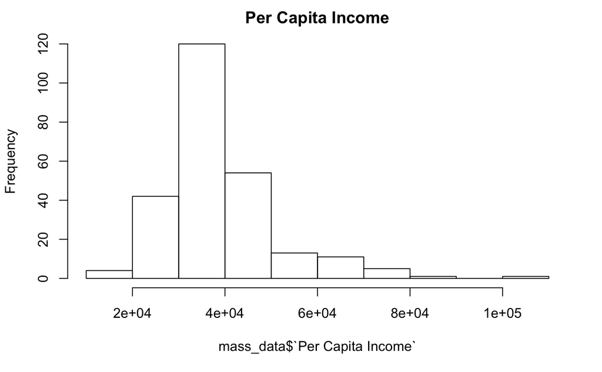

```r
# 1. Build histogram to assess normality/distribution
hist(mass_data$`Per Capita Income`, main='Per Capita Income')
```

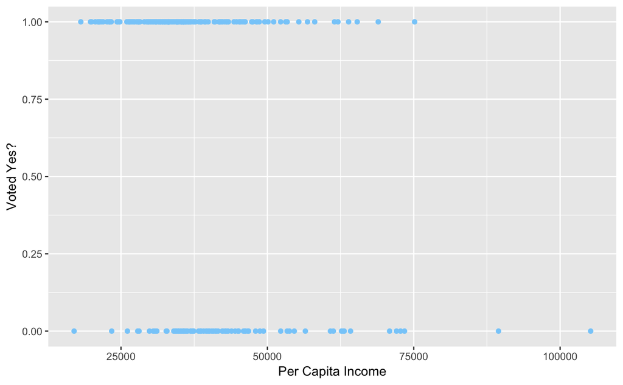

```r
# Based on histogram, 'Per Capita Income' appears to be
# skewed right (not normally distributed)
# 2. Build scatterplot to test for outliers,
# view any relationship between population and voting yes
ggplot(data=mass_data) + geom_point(mapping=aes(x=`Per Capita Income`, y=`Voted Yes?`), color="lightskyblue")
```

```r
# Based on the histogram and scatterplot, it looks as though there
# might be some outliers in this data set: will remove
# 3. Use Spearman's to calculate correlation
correlation_per_capita_income <- cor.test(mass_data$`Per Capita Income`,
                      mass_data$`Voted Yes?`, method="spearman")
```

```
Cannot compute exact p-value with ties
```

```r
correlation_per_capita_income
```

```
    Spearman's rank correlation rho

data:  mass_data$`Per Capita Income` and mass_data$`Voted Yes?`
S = 3504000, p-value = 9.052e-08
alternative hypothesis: true rho is not equal to 0
sample estimates:
       rho
-0.3295353
```

```r
# The calculated coefficient of correlation is calculated to be
# -0.3295353, meaning that there is a weak downhill/negative linear
# relationship between a precinct's per capita income and
# and whether or not they voted for the legalization of marijuana.
# The p-value is 9.052e-08, making it smaller than 0.05,
# meaning that it is statistically significant.
```

*Median Household income*

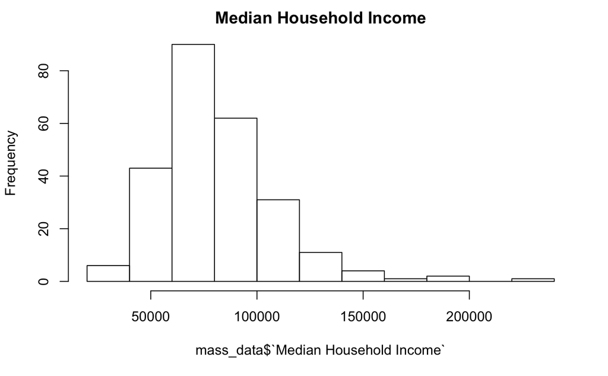

```r
# 1. Build histogram to assess normality/distribution
hist(mass_data$`Median Household Income`, main='Median Household Income')
```

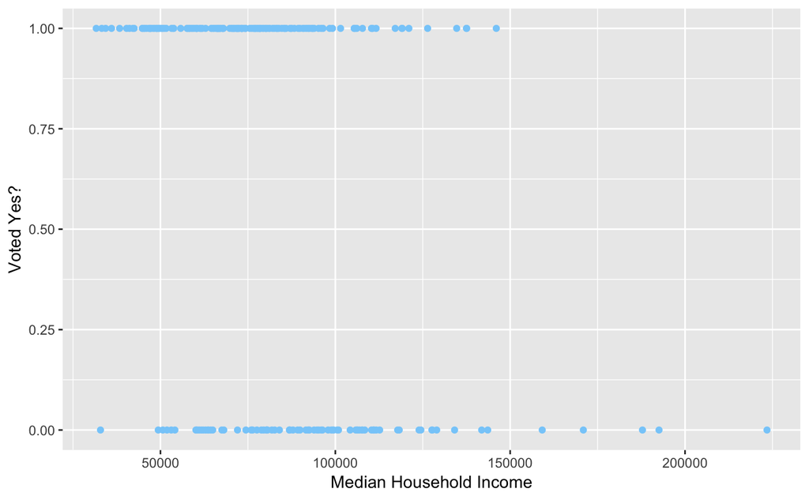

```r
# Based on histogram, 'Median Household Income' appears to be
# skewed right (not normally distributed)
# 2. Build scatterplot to test for outliers,
# view any relationship between population and voting yes
ggplot(data=mass_data) + geom_point(mapping=aes(x=`Median Household Income`,
                                                y=`Voted Yes?`), color="lightskyblue")
```

```r
# Based on the histogram and scatterplot, it looks as though there
# might be some outliers in this data set: will remove later
# 3. Use Spearman's to calculate correlation
correlation_median_household_income <- cor.test(mass_data$`Median Household Income`,
                      mass_data$`Voted Yes?`, method="spearman")
```

```
Cannot compute exact p-value with ties
```

```r
correlation_median_household_income
```

```
    Spearman's rank correlation rho

data:  mass_data$`Median Household Income` and mass_data$`Voted Yes?`
S = 3548200, p-value = 1.755e-08
alternative hypothesis: true rho is not equal to 0
sample estimates:
      rho
-0.346315
```

```r
# The calculated coefficient of correlation is calculated to be
# -0.346315, meaning that there is a weak downhill/negative linear
# relationship between a precinct's median household income and
# and whether or not they voted for the legalization of marijuana.
# The p-value is 1.755e-08, making it smaller than 0.05,
# meaning that it is statistically significant.
```

*Median Family Income*

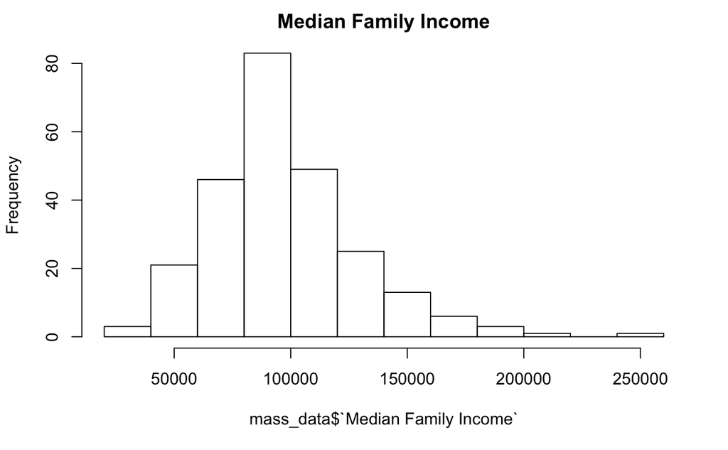

```r
# 1. Build histogram to assess normality/distribution
hist(mass_data$`Median Family Income`, main='Median Family Income')
```

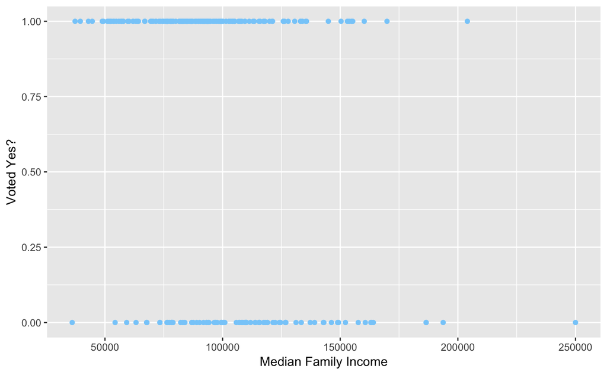

```r
# Based on histogram, 'Median Household Income' appears to be
# skewed right (not normally distributed)
# 2. Build scatterplot to test for outliers,
# view any relationship between population and voting yes
ggplot(data=mass_data) + geom_point(mapping=aes(x=`Median Family Income`,
                                                y=`Voted Yes?`), color="lightskyblue")
```

```r
# Based on the histogram and scatterplot, it looks as though there
# might be some outliers in this data set: will remove later
# 3. Use Spearman's to calculate correlation
correlation_median_family_income <- cor.test(mass_data$`Median Family Income`,
                      mass_data$`Voted Yes?`, method="spearman")
```

```
Cannot compute exact p-value with ties
```

```r
correlation_median_family_income
```

```
    Spearman's rank correlation rho

data:  mass_data$`Median Family Income` and mass_data$`Voted Yes?`
S = 3475100, p-value = 2.508e-07
alternative hypothesis: true rho is not equal to 0
sample estimates:
       rho
-0.3185819
```

```r
# The calculated coefficient of correlation is calculated to be
# -0.3185819, meaning that there is a weak downhill/negative linear
# relationship between a precinct's median family income and
# and whether or not they voted for the legalization of marijuana.
# The p-value is 2.508e-07, making it smaller than 0.05,
# meaning that it is statistically significant.
```

*Population*

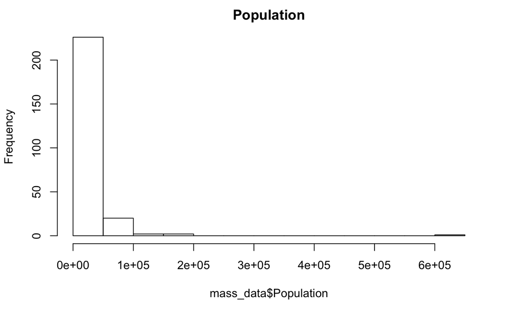

```r
# 1. Build histogram to assess normality/distribution
hist(mass_data$Population, main='Population')
```

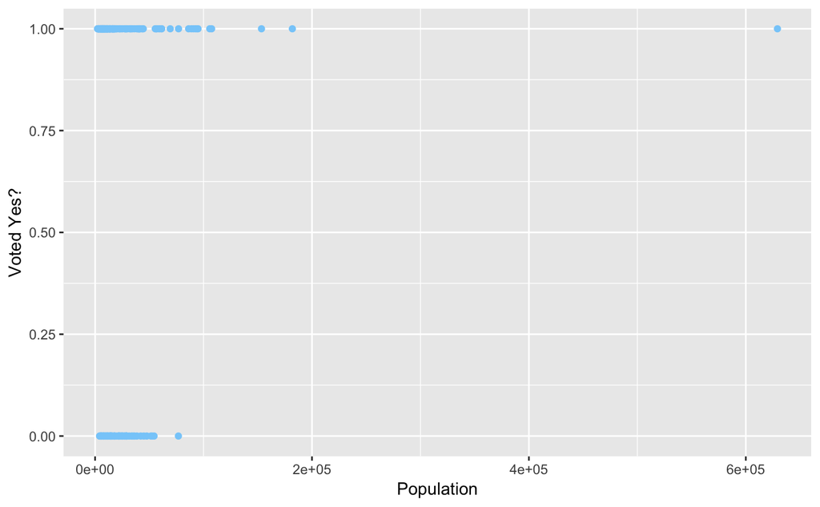

```r
# Based on histogram, 'Median Household Income' appears to be
# skewed right (not normally distributed)
# 2. Build scatterplot to test for outliers,
# view any relationship between population and voting yes
ggplot(data=mass_data) + geom_point(mapping=aes(x=`Population`, y=`Voted Yes?`),
                                    color="lightskyblue")
```